# Lab 3 - Exploring Many Categorical Variables with R

## Introduction

This practical will lead you into producing some high quality visualisations of multivariate categorical data.

By the end of the lab, you will have acquired the following skills:

- Plotting stacked barplots for simple data sets
- Plotting `doubledecker` and `mosaicplot` plots for more complex data sets

**You will need to install the following packages**:

- `vcd` for the `doubledecker` functions

```r
install.packages("vcd")
```

## Exercise 1 (Mosaicplots)

Displaying combinations of categorical variables can be quite difficult, as we can’t represent our data as simple points in a space. Instead, we summarise a categorical variable (e.g. eye colour) with multiple levels (blue, green, brown, …) by the frequencies of each of the levels in the data. When we have multiple categorical variables, we work instead with the counts of the combinations of the levels (e.g. red hair + green eyes).

All of our plots are some sort of visualisation of these counts and so are (in one way or another) variations and manipulations of stacked barplots. Multivariate categorical data is a little more complex to work with, so generally it is recommended to start with single or pairs of variables and progressively add more, rather than visualising everything all at once like a scatterplot matrix.

Download data: arthritis

The `arthritis` data contains the results from a double-blind clinical trial investigating a new treatment for rheumatoid arthritis. The variables are:

- `ID` - patient ID.
- `Treatment` - factor indicating treatment (Placebo, Treated).
- `Sex` - factor indicating sex (Female, Male).
- `Age` - age of patient.
- `Improved` - ordered factor indicating treatment outcome (None, Some, Marked).

`Treatment`, `Sex`, and `Improved` are all categorical variables. `Improved` is also ordinal, since the category levels can be ordered. The question is whether the patient improvement depends on the Treatment and Sex.

Mosaic plots can display the relationship between categorical variables using rectangular tiles, whose areas represent the proportion of cases for any given combination of levels. A mosaic plot of a single variable is basically a simple stacked barplot with only one bar. Looking at the patient improvement only, we see the following

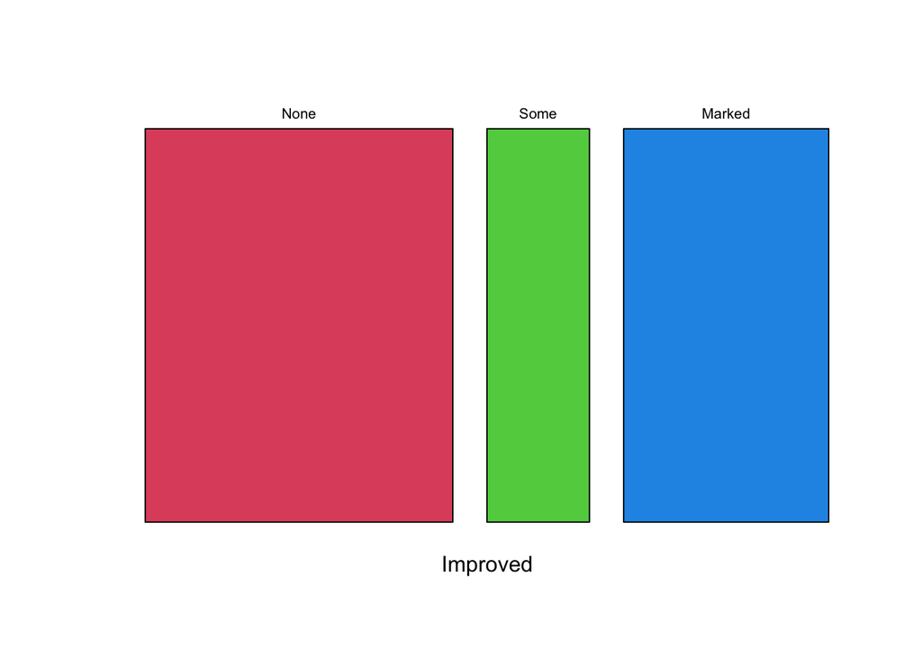

```r
mosaicplot(~Improved, data=arthritis,col=2:4,main='')
```

Since the `None` box is largest, we see that this appears to be the most common patient outcome. But taking the `Some` and `Marked` improvements together, it’s actually an even split. Let’s see how this depends on what `Treatment` the patient received - we would hope to see more improvement from those in the `Treated` group:

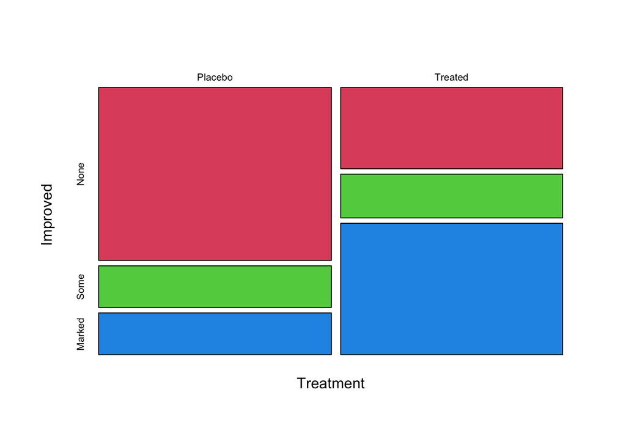

```r
mosaicplot(~Treatment+Improved, data=arthritis,col=2:4,main='')
```

However, we can see clearly that a greater proportion of patients improved on treatment than in the placebo group and so the distribution of `Improved` is different for different values of `Treatment`, which may point towards an association between these variables and maybe hints at treatment being effective!

If we reverse the positions of `Improved` and `Treatment` in the function, it change the order in which the bars are split:

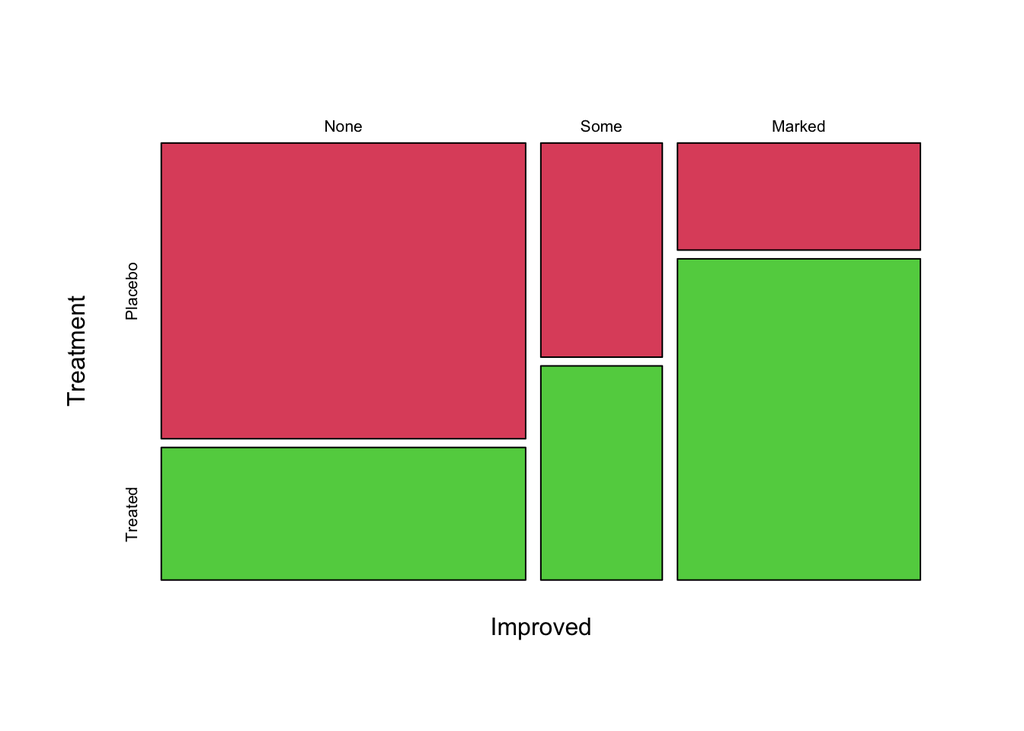

### **Task 1b** {-} * Using the `mosaicplot` command, try to reproduce the mosaicplot above * What are the new features that become apparent when you reverse the positions of the variables?

**Click for solution**

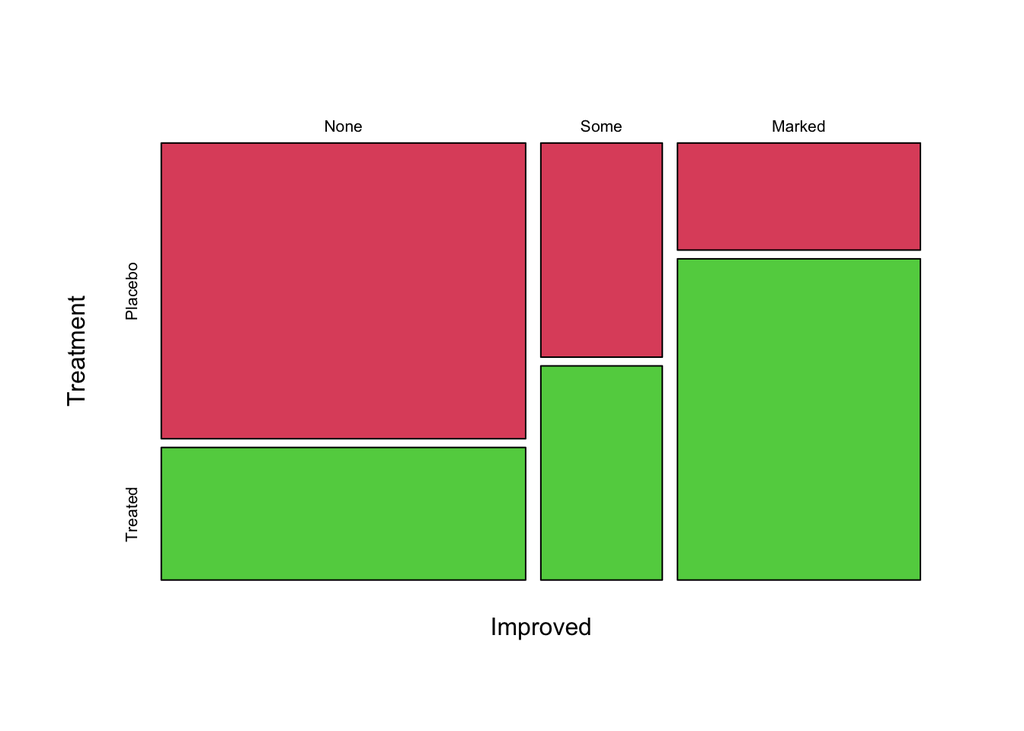

```r
mosaicplot(~Improved+Treatment, data=arthritis, col=2:4,main='')
```

Now we have three vertical bars for `Improved`, each sub-divided into the `Treatment` groups. This plot now shows how the patients with different `Improved` levels break down into the `Treatment` groups. So, we would read this as saying for those patients with a Marked improvement, the majority were Treated rather than given Placebo. Usually, it is best to split on the response variable at the end, as we had done in the previous plot.

### More variables

We can continue to add variables to the plot and break down the results into more groups. For instance, we can introduce `Sex` as a variable

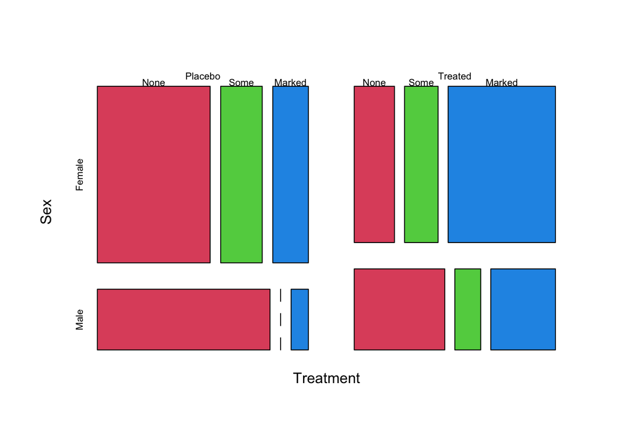

```r
mosaicplot(~Treatment+Sex+Improved, data=arthritis,col=2:4,main='')
```

Here we can see:

- The Treatment groups look to be roughly equal in size
- There are fewer men than women in the study (the `Male` rows are narrower than the `Female`)
- There are no `Male` patients in the `Placebo` group who only had `Some` improvement - this is indicated by the dashed line where this bar should be.
- `Treatment` appears to have a positive effect
- `Female` patients seemed to improve the most in general, and particularly under `Treatment`

It is often worth reordering the variables in the mosaic plot formula to see if a different sequence of splits is a more effective visualisation for your problem. Generally, our dependent variable of interest is split last following the `~` in the function call.

### **Task 1b**

- Produce mosaicplots of combinations of one, two and three variables for the built-in R data set `HairEyeColor`
- Experiment with the ordering of the variables in the call to the `mosaicplot` function to see how different orderings produce different presentations of the data.
- Which visualisation best highlights the interesting patterns in the data?

**Click for solution**

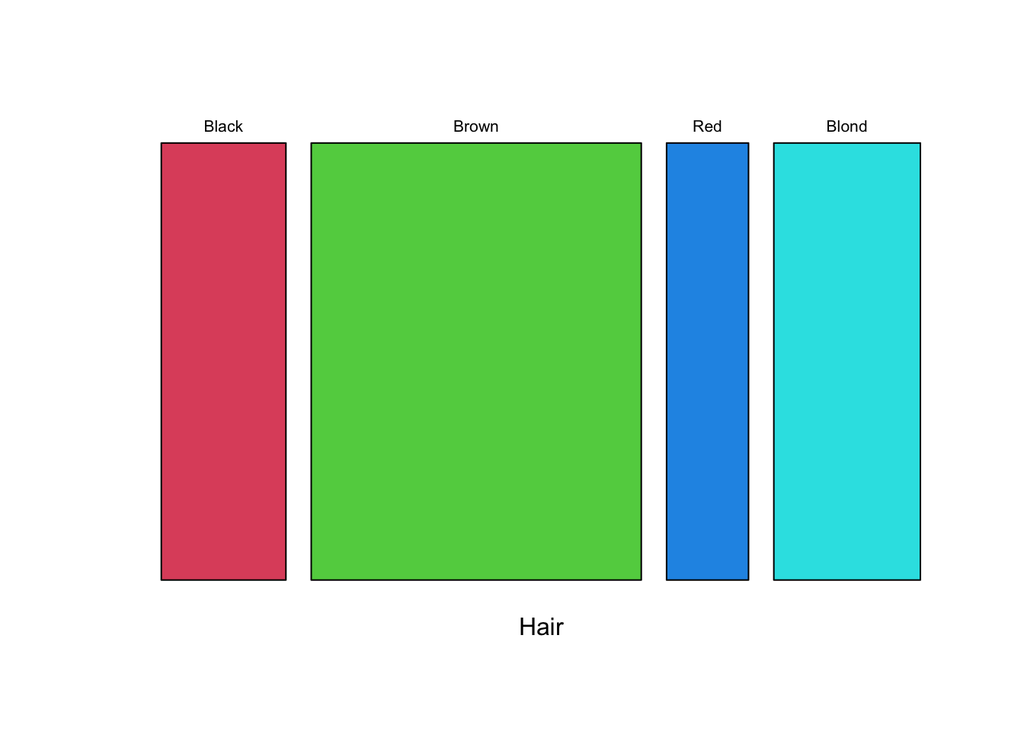

```r
data("HairEyeColor")

mosaicplot(~Hair, data=HairEyeColor,col=2:5,main='')
```

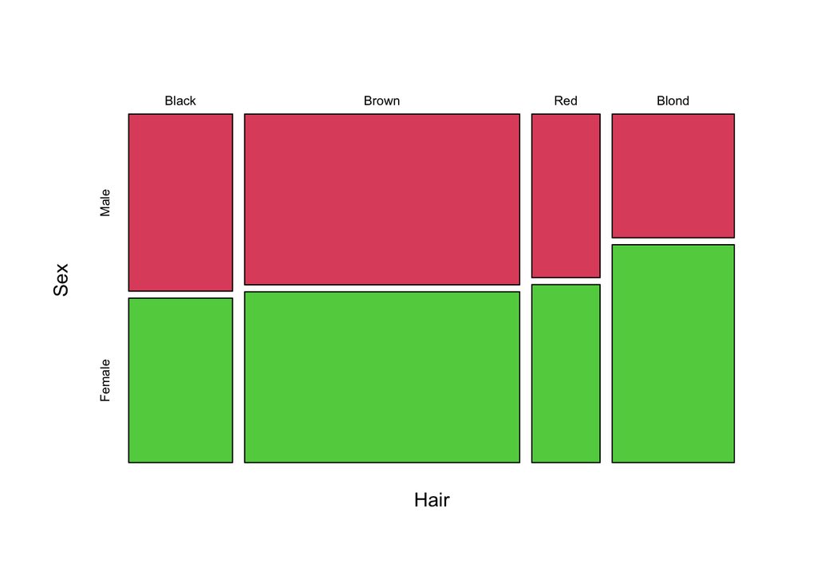

```r
mosaicplot(~Hair+Sex, data=HairEyeColor,col=2:5,main='')
```

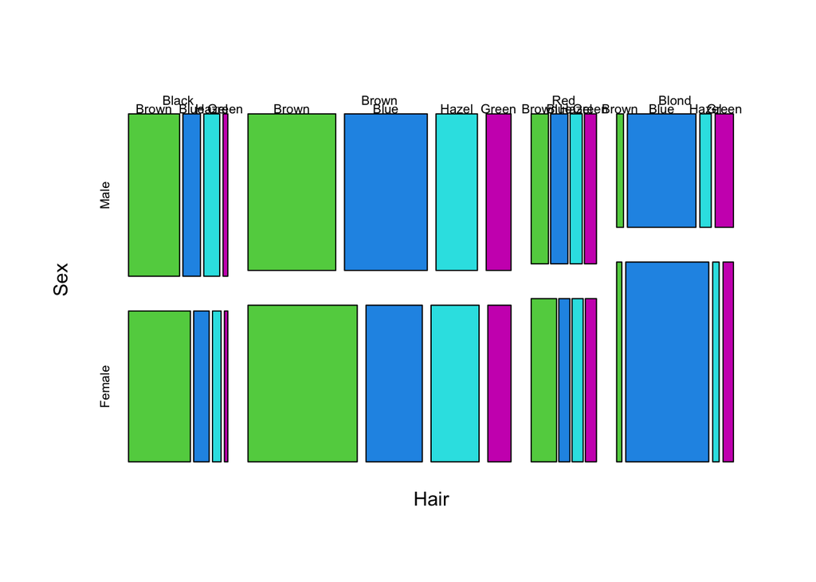

```r
## With three variables there are 6 different orderings - here are a couple (with a different coloring option)
mosaicplot(~Hair+Sex+Eye, data=HairEyeColor,col=3:6,main='')
```

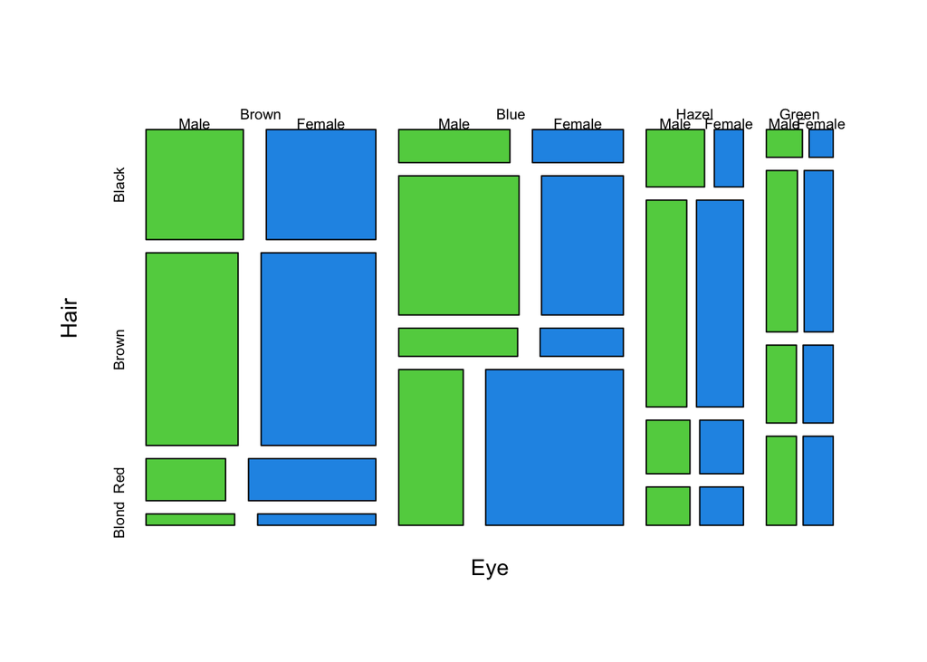

```r
mosaicplot(~Eye+Hair+Sex, data=HairEyeColor,col=3:6,main='')
```

### Directions of the splits

A `doubledecker` plot is a version of a mosiac plot where all of the splits in the data are vertical, except for the last one. This effectively produces a type of stacked barplot, which we can achieve by setting the `dir`ection argument as follows:

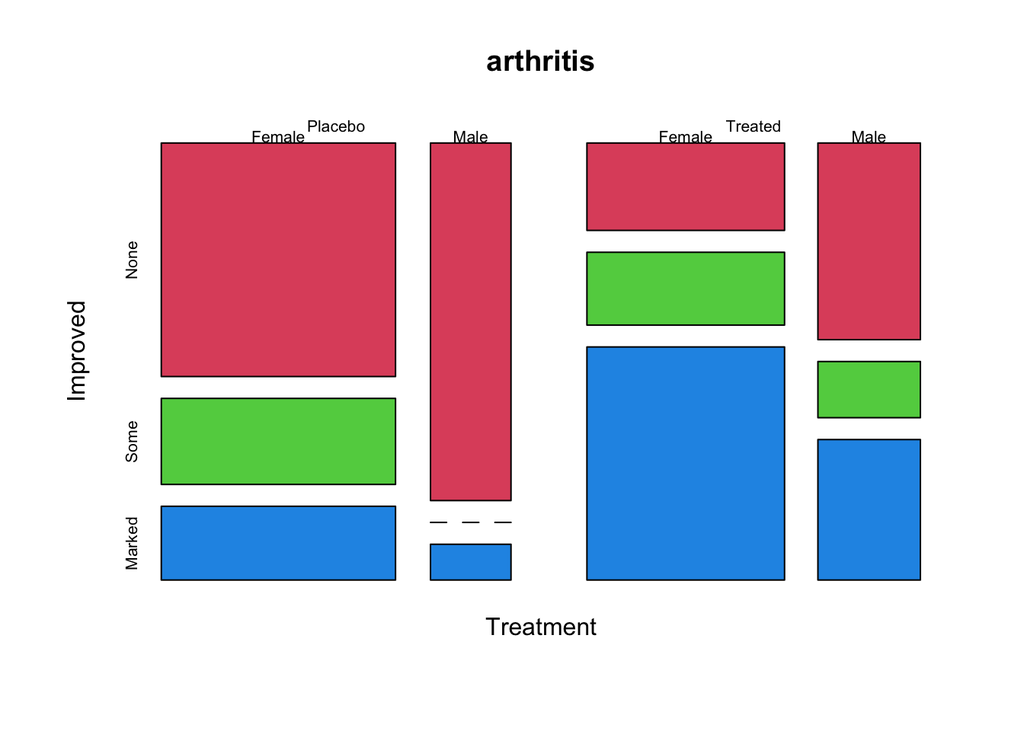

```r
mosaicplot(~Treatment+Sex+Improved, data=arthritis, dir = c("v", "v", "h"),col=2:4)
```

Or, using the `doubledecker` function directly gives an almost identical plot:

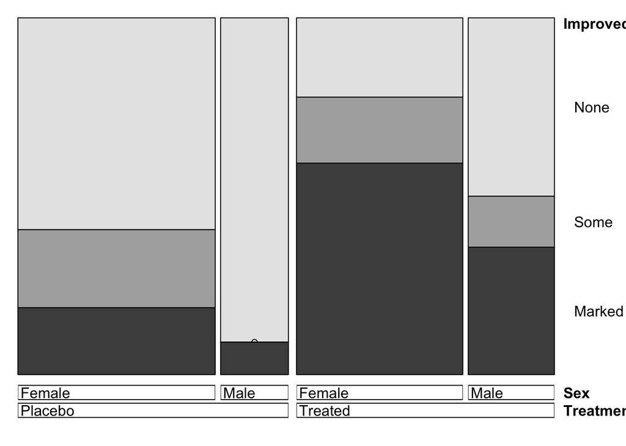

```r
doubledecker(Improved~Treatment+Sex, data=arthritis)
```

### Adding some colour

The default plots are somewhat dull and monochrome. Note that the different shadings used in the plot correspond to the different levels of the last cut variable, i.e. the dependent variable which is `Improved` here. So, if we supply one colour for each level of that variable we get the following plot:

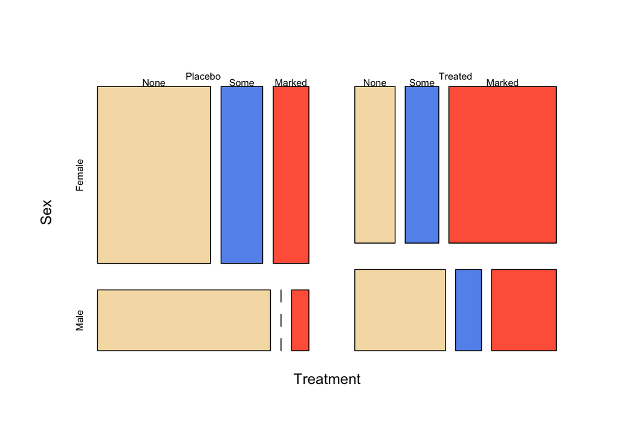

```r
mosaicplot(~Treatment+Sex+Improved, data=arthritis, main='', col=c("wheat", "cornflowerblue", "tomato1"))
```

Note: In general, setting colours on mosaic plots can be quite fiddly. We won’t make much use of it, apart from an automatic coloring technique that we describe below.

## Using colour to highlight unexpected patterns

A different but helpful use of colour is the `shade=TRUE` option. The `shade=TRUE` option works by colouring any tiles in the mosaic that are in disagreement with the independence hypothesis of a chi-square test. This can help us identify any combinations that are unusually common or rate:

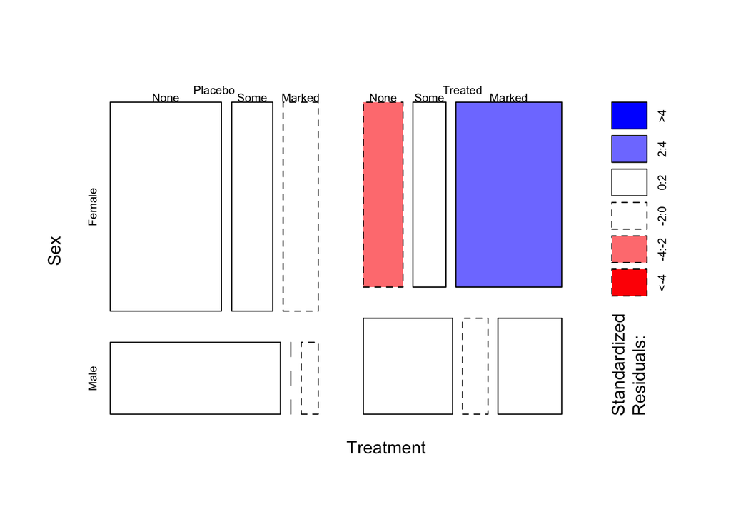

```r
mosaicplot(~Treatment+Sex+Improved, data=arthritis,shade=TRUE,main='')
```

Tiles are shaded blue when more cases are observed than expected given independence, and shaded red when there are fewer cases than expected under independence. The strength of colour indicates how “surprising” those values are. The plot here is showing that most of the variation is not significant (coloured white), but in the `Female` and `Treated` group there is a surprisingly high number of patients who display a `Marked` improvement (blue-ish) - and consequently, fewer than expected (red-ish) whose improvement was `None`.

### **Task 1c**

- Use the `mosaicplot` function with `shade` and the `dir` arguments to create a “doubledecker” version of the mosaic plot above.

**Click for solution**

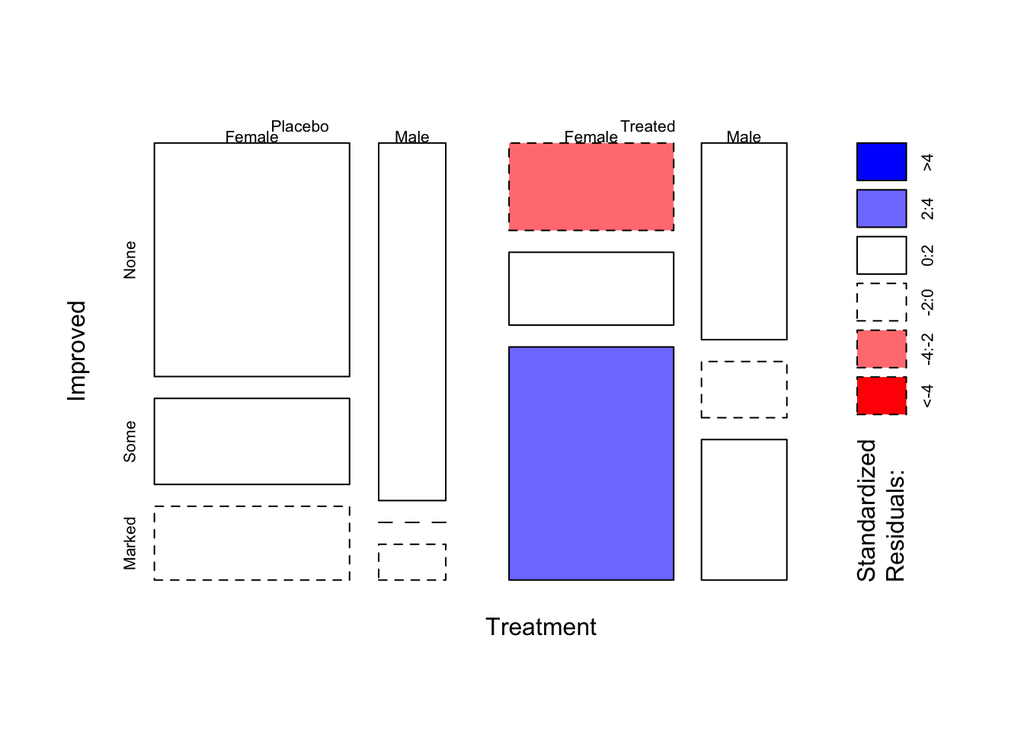

```r
mosaicplot(~Treatment+Sex+Improved, data=arthritis, shade=TRUE, main='',dir = c("v", "v", "h"))
```

## Exercise 2: Mosaicplots on a data set containing counts

Download data: alligator

The `alligator` data, from Agresti (2002), comes from a study of the primary food choices of alligators in four Florida lakes. The goal is to try and learn something about the food choice of the different alligators. The variables are:

- `lake` - one of four lakes: `George`, `Hancock`, `Oklawaha`, and `Trafford`
- `sex` - `male` or `female`
- `size` - `small` or `large`
- `food` - the food preferences of the alligators in five categories: `fish`, `invert`ebrates, `reptile`, `bird` and `other`.

As usual, we begin with a quick look at the data to see what we’re dealing with:

```r
head(alligator)
```

| lake | sex | size | food | count |
| --- | --- | --- | --- | --- |
| Hancock | male | small | fish | 7 |
| Hancock | male | small | invert | 1 |
| Hancock | male | small | reptile | 0 |
| Hancock | male | small | bird | 0 |
| Hancock | male | small | other | 5 |
| Hancock | male | large | fish | 4 |

Here, unlike the `arthritis` data, each row does not represent an individual alligator but all of the alligators found with the given combinations of categorical variables. So, for example, we have seen 7 alligators with attributes (`Hancock`, `male`, `small`, `fish`). This is a slightly different format than we saw above, so we’ll need to deal with it slightly differently.

To produce the counts needed for our plots, we need to use the cross-tabulation function `xtabs` that we used with our `barplot`s. So, to generate the counts of alligators in each lake, we first compute

```r
xtabs(count~lake, data=alligator)
```

```
## lake
##   George  Hancock Oklawaha Trafford
##       63       55       48       53
```

and then pass this to our `mosaic` function for plotting:

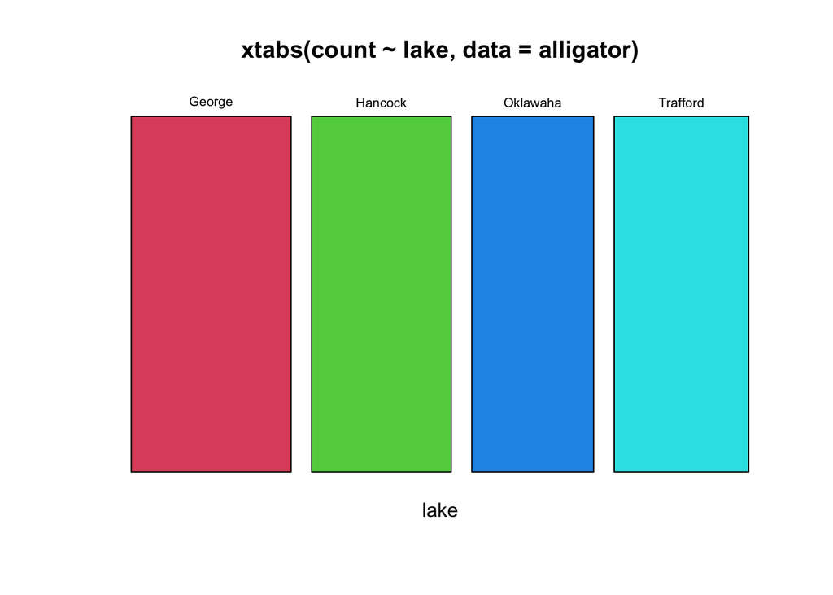

```r
mosaicplot(xtabs(count~lake, data=alligator),col=2:5)
```

Alternatively, with a single variable we could just draw a `barplot`, which is probably a little easier to read!

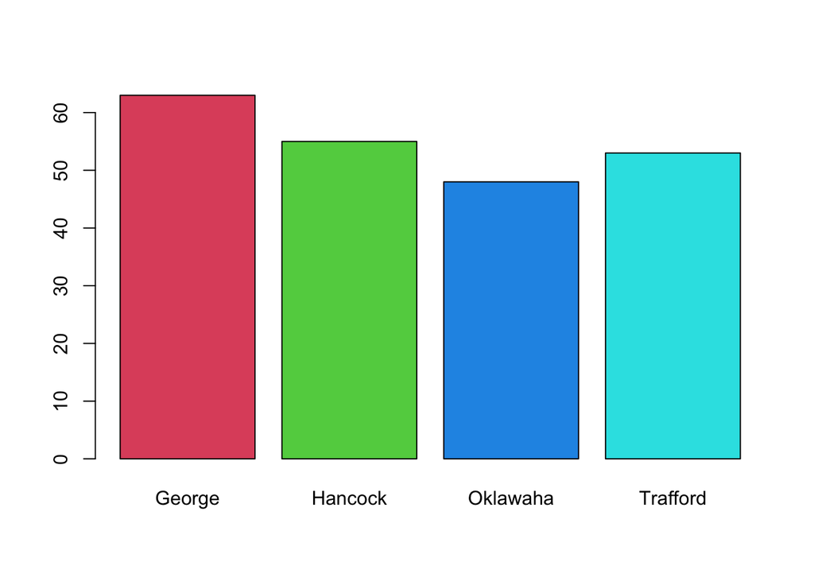

```r
barplot(xtabs(count~lake, data=alligator),col=2:5)
```

Note that the mosaicplot is showing the proportions in the different lakes by the width of the bars, whereas the barplot uses the height. We see there are slight differences between the numbers of alligators observed in the different lakes, but they don’t appear to be substantial.

Note that the only difference with working with these data (which include the counts as a variable) and the previous data set (which did not include the counts) is that we must do the aggregating of the data in the `xtabs` function first, instead of directly in `mosaicplot`. The syntax and formula for splitting the data is the same.

### **Task 2a**

- Investigate the distributions of the other categorical variables individually: `sex`, `size`, and `food`. You can use whatever plot you prefer. Try and answer the following questions:
  - Are the sexes of alligators evenly distributed?
  - What about the different sizes?
  - Which food type is most popular?

**Click for solution**

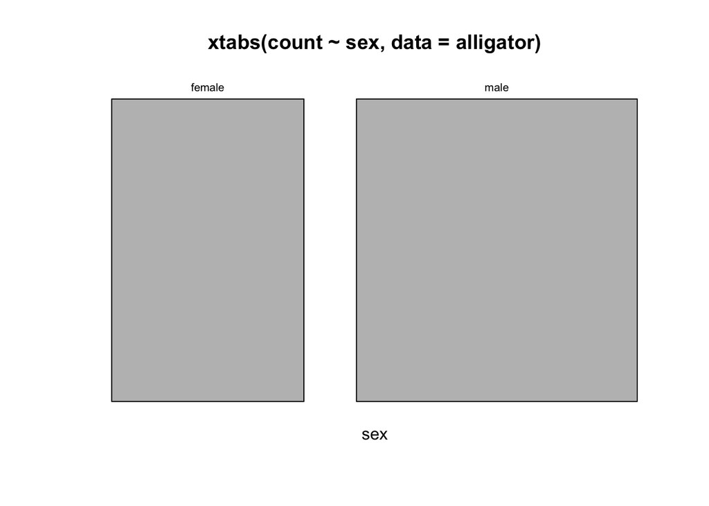

```r
mosaicplot(xtabs(count~sex, data=alligator))
```

More males than female

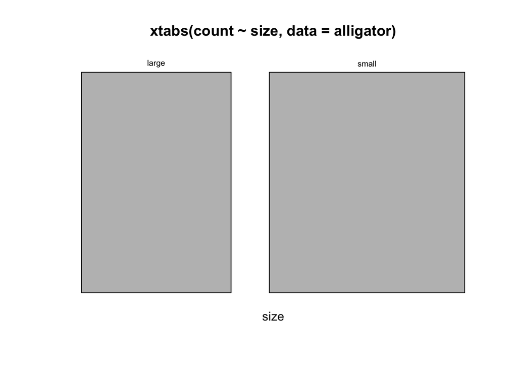

```r
mosaicplot(xtabs(count~size, data=alligator))
```

slightly more small than large

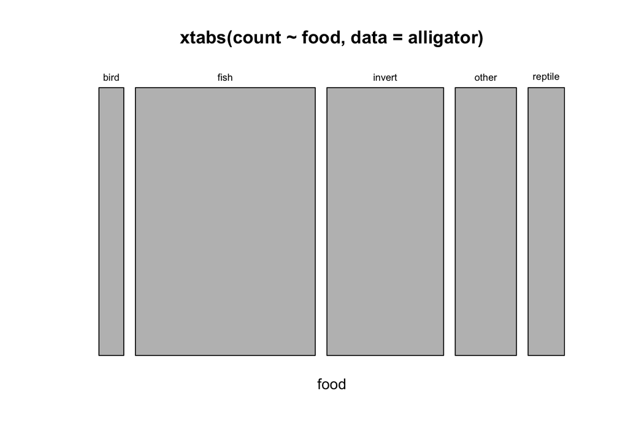

```r
mosaicplot(xtabs(count~food, data=alligator))
```

mostly eat fish, then invertebrates.

### More than two variables

The strength of mosaic plots is when considering the combination of multiple categorical variables at once. To keep things manageable, let’s looks at some potentially interesting pairs of variables first:

### **Task 2b**

- Use `mosaicplot` to visualise the `size` and `sex` variables together. Remember, if there is no association here then we would expect a regular grid. What associations do you find?
- What about `size` and `food`?
- Draw the `doubledecker` plots of the same variables - how do they compare to the mosaic plot?

**Click for solution**

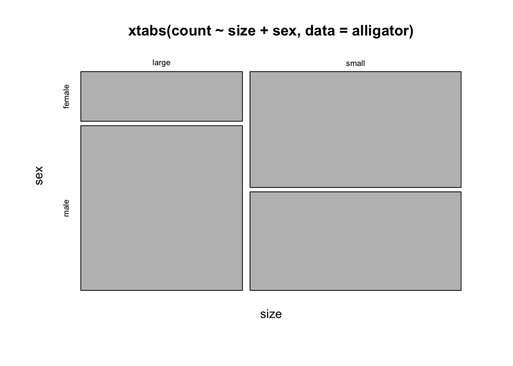

```r
mosaicplot(xtabs(count~size+sex, data=alligator))
```

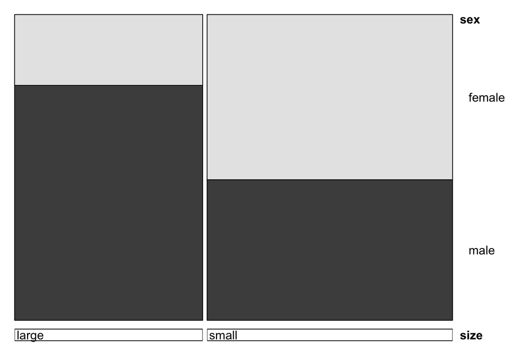

```r
doubledecker(xtabs(count~size+sex, data=alligator))
```

more males are larger, females are smaller

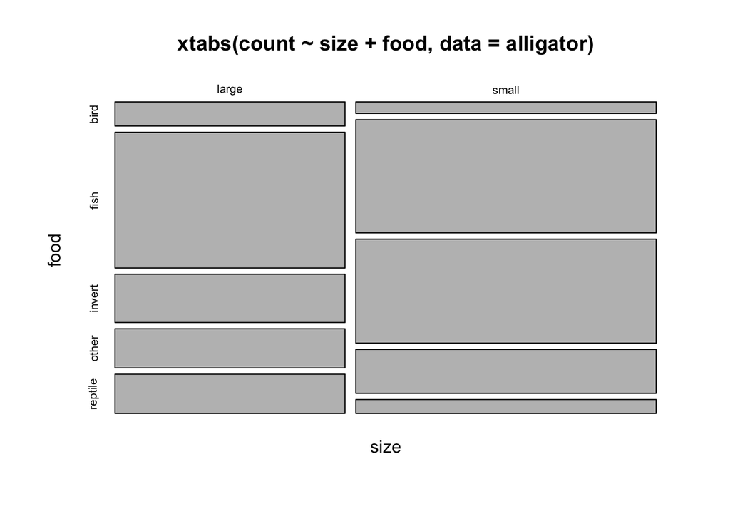

```r
mosaicplot(xtabs(count~size+food, data=alligator))
```

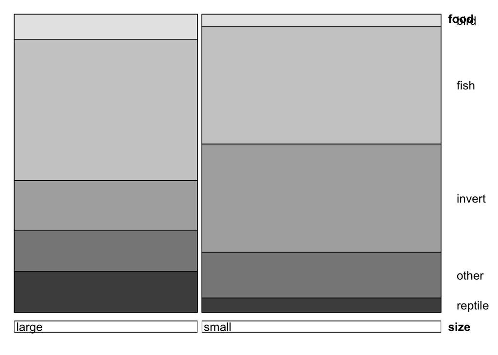

```r
doubledecker(xtabs(count~size+food, data=alligator))
```

big alligators eat more fish+reptile, and less invertebrates.

We can even make a matrix of **all** the two-way mosaic plots in the style of a scatterplot matrix by the following command:

```r
pairs(xtabs(count~.,data=alligator))
```

[output not shown]

Using a `.` on the right side of the formula is a shorthand for “include everything”.

### **Task 2c**

- Can you locate the plots of `size` and `sex`, and `size` and `food` within the matrix?
- Do you see any other potential associations (or lack of associations) here? Remember, “no association” will mean the mosaic is divided into an approximately regular grid.
- Make a doubledecker plot of `food`, `size` and `sex` - order the variables so that each bar is split into sections according to the `food`.
- Now try the mosaic plot and use the `shade=TRUE` option. Try and achieve the same ordering so that food is the final split. What combinations have been highlighted, and how would you interpret them?
- Do you see any other potentially interesting features here?

**Click for solution**

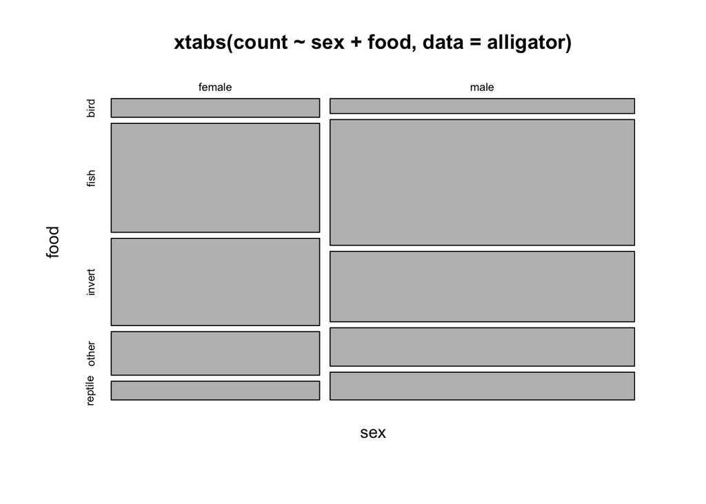

```r
mosaicplot(xtabs(count~sex+food, data=alligator))
```

This looks pretty regular, no obvious surprisingly large/small blocks. Let’s try shading the big plot for more emphasis

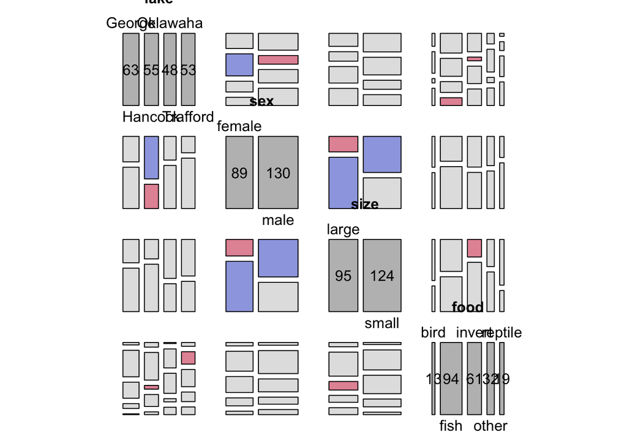

```r
pairs(xtabs(count~.,data=alligator), shade=TRUE)
```

Combining more that two variables in a mosaic can get a bit crazy. Let’s look at `size`, `sex` and `food` all together.

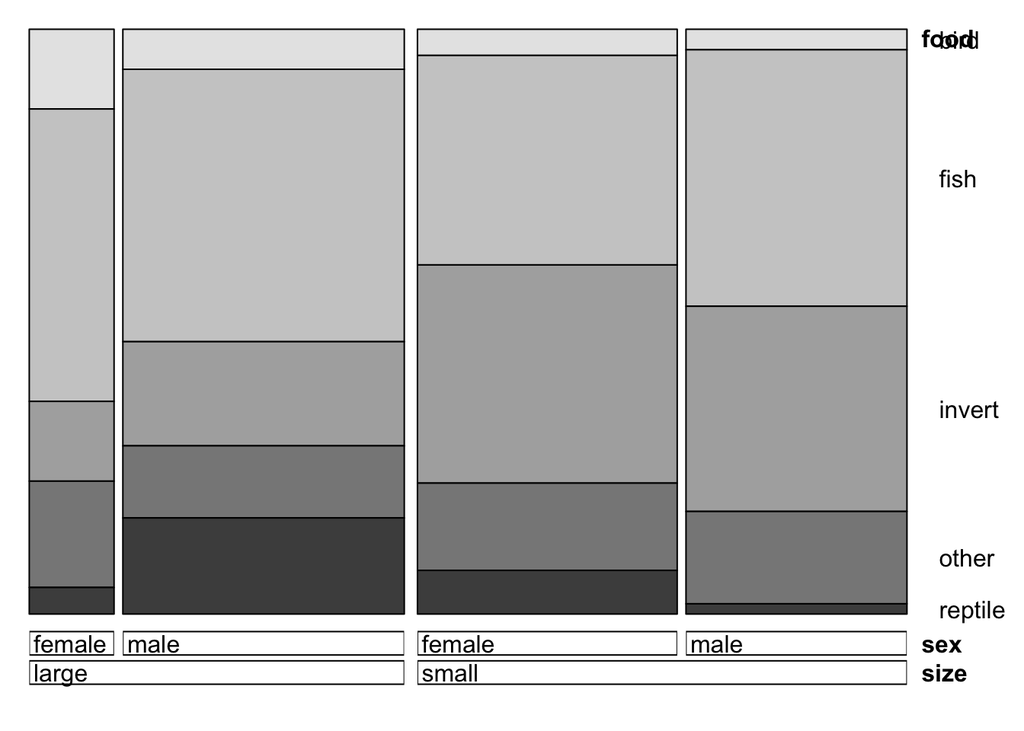

```r
doubledecker(xtabs(count~size+sex+food, data=alligator))
```

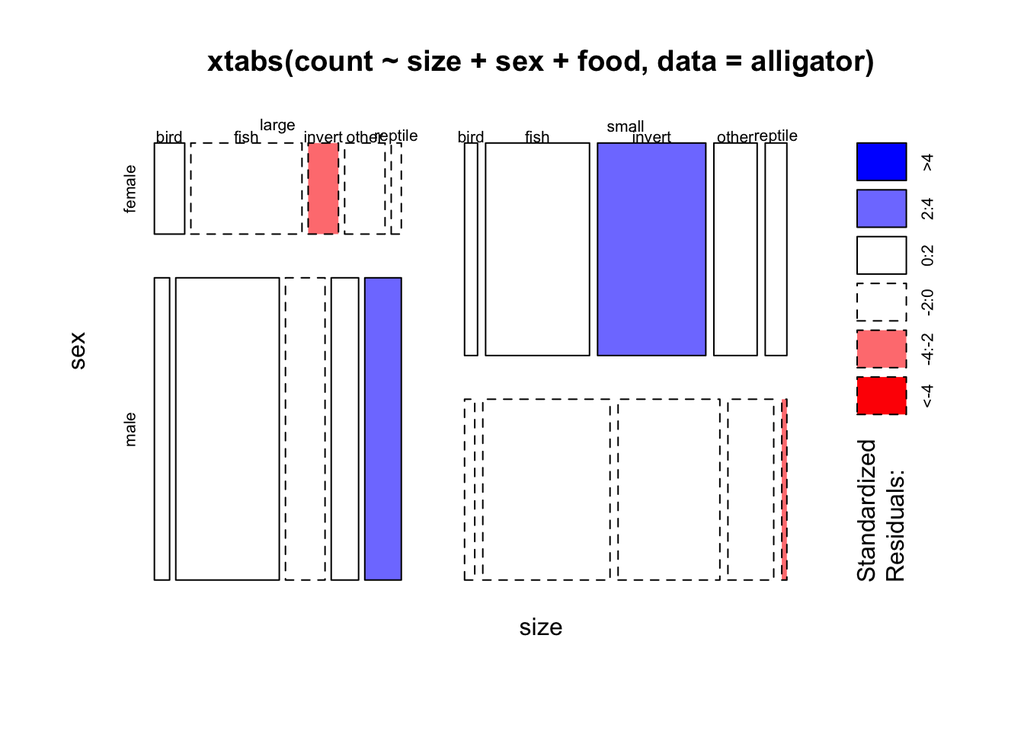

```r
mosaicplot(xtabs(count~size+sex+food, data=alligator),shade=TRUE)
```

Large males eat more reptiles, small males eat surprisingly few (are they eating each other…?) Small females eat more invertebrates, large females eat few

The four-way table goes a bit mad

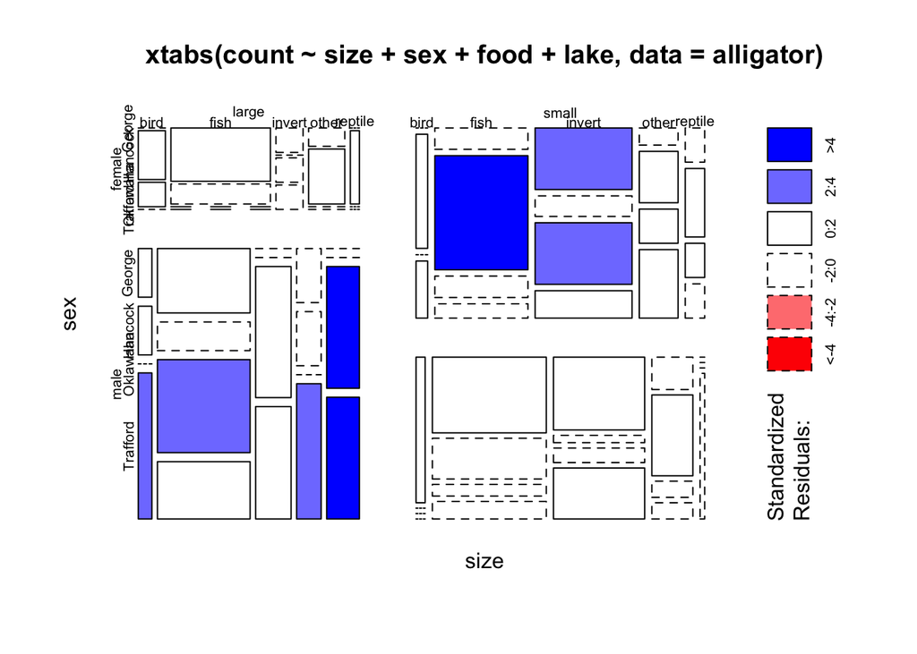

```r
mosaicplot(xtabs(count~size+sex+food+lake, data=alligator),shade=TRUE)
```

but does reveal some features that may be worth digging into, though it has become very hard to digest.

## Exercise 3 (for extra practice): Grouped and stacked barplots

Barplots can be used effectively to display combinations of categorical variables. However, they require a little more setup to provide the data in the correct format.

First, a grouped barplot displays a numeric value (e.g. counts) split in groups and subgroups. A few explanation about the code below: * the input dataset must be a numeric matrix. Each group is a column. Each subgroup is a row. So we can only deal with two variables at once. * the `barplot` function will recognize this format, and automatically perform the grouping for you. * the `beside` option allows to toggle between the grouped and the stacked barchart

```r
## make a table of counts by Treatment and Improved from the arthritis data
tab <- xtabs(~Improved+Treatment,data=arthritis)
tab
```

```
##         Treatment
## Improved Placebo Treated
##   None        29      13
##   Some         7       7
##   Marked       7      21
```

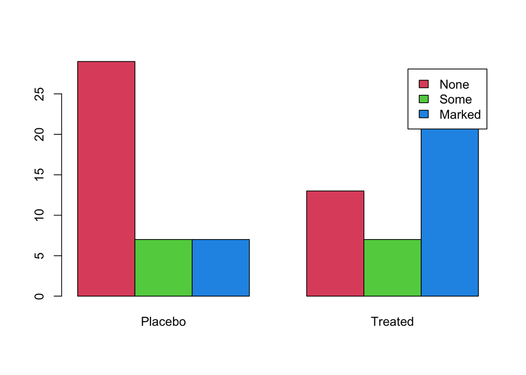

```r
# Grouped barplot
barplot(tab, beside=TRUE, legend=rownames(tab), col=2:4)
```

And to stack the bars, set `beside=FALSE`

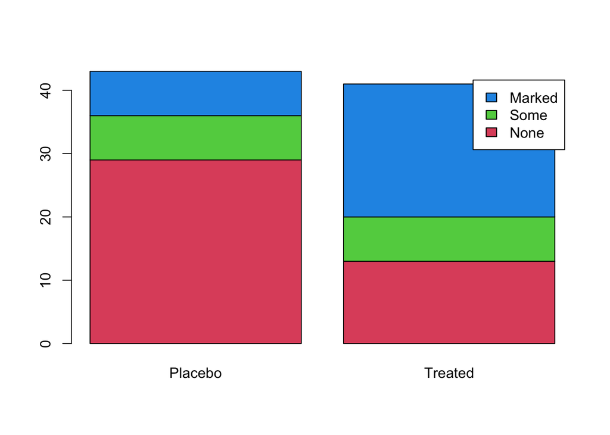

```r
barplot(tab, beside=FALSE, legend=rownames(tab), col=2:4)
```

Stacked bars are often used to display the *proportions* of the respective columns attributable to each sub-group. Thankfully, we can easily convert tables of counts to proportions with the `prop.table` function. If we want the proportions computed within a column, set the `margin=2` argument:

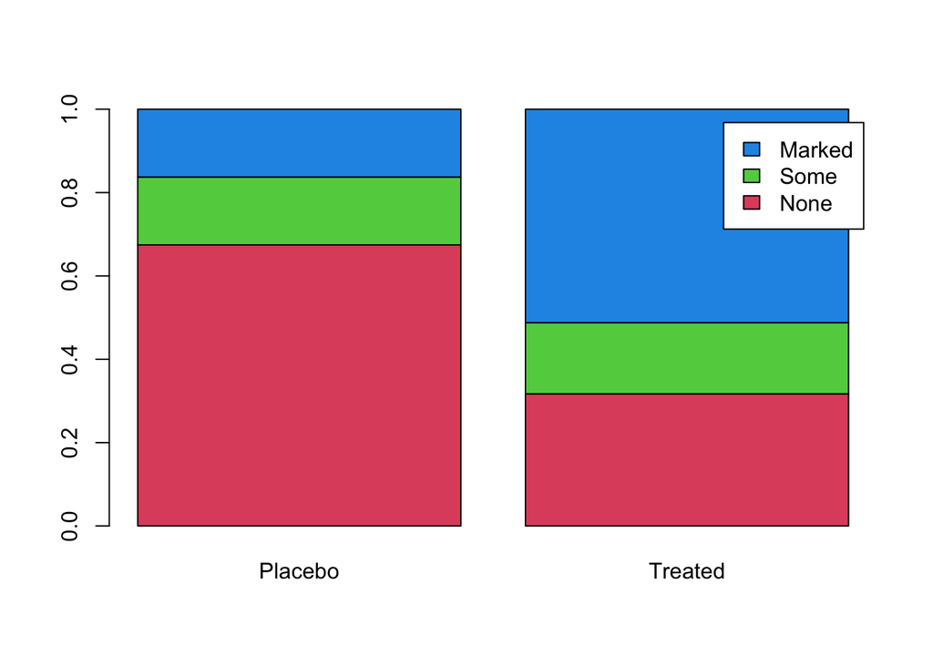

```r
barplot(prop.table(tab, margin=2), beside=FALSE, legend=rownames(tab), col=2:4)
```